# Ćwiczenia 3

Patrycja Piła

2022-11-06

# Zestaw 2

## Zadanie 7

Wyznaczam podstawowe statystyki opisowe dot. wielkości populacji na różnych kontynentach w roku 2007.

```r
library(dplyr)
library(gapminder)

populacja <- gapminder %>%
  filter(year == "2007") %>%
  group_by(continent)%>%
  summarize(srednia = mean(pop),
            odchylenie =sd(pop),
            mediana = median(pop),
            kwant = quantile(pop),
            rozstęp =IQR(pop))
populacja
```

```
## # A tibble: 25 × 6
## # Groups:   continent [5]
##    continent   srednia odchylenie   mediana      kwant  rozstęp
##    <fct>         <dbl>      <dbl>     <dbl>      <dbl>    <dbl>
##  1 Africa    17875763.  24917726. 10093310.    199579  16454428
##  2 Africa    17875763.  24917726. 10093310.   2909226. 16454428
##  3 Africa    17875763.  24917726. 10093310.  10093310. 16454428
##  4 Africa    17875763.  24917726. 10093310.  19363654. 16454428
##  5 Africa    17875763.  24917726. 10093310. 135031164  16454428
##  6 Americas  35954847.  68833781.  9319622    1056608  22999401
##  7 Americas  35954847.  68833781.  9319622    5675356  22999401
##  8 Americas  35954847.  68833781.  9319622    9319622  22999401
##  9 Americas  35954847.  68833781.  9319622   28674757  22999401
## 10 Americas  35954847.  68833781.  9319622  301139947  22999401
## # … with 15 more rows
```

## Zadanie 8

```r
top_3 <-gapminder %>%
  filter(year == "1977",
         gdpPercap > 5000,
         continent %in% c('Africa', "Europe", "Americas")) %>%
  group_by(continent) %>%
  top_n(3, lifeExp) %>%
  arrange(country, desc(lifeExp))
top_3
```

```
## # A tibble: 9 × 6
## # Groups:   continent [3]
##   country       continent  year lifeExp       pop gdpPercap
##   <fct>         <fct>     <int>   <dbl>     <int>     <dbl>
## 1 Canada        Americas   1977    74.2  23796400    22091.
## 2 Gabon         Africa     1977    52.8    706367    21746.
## 3 Iceland       Europe     1977    76.1    221823    19655.
## 4 Libya         Africa     1977    57.4   2721783    21951.
## 5 Puerto Rico   Americas   1977    73.4   3080828     9771.
## 6 South Africa  Africa     1977    55.5  27129932     8029.
## 7 Sweden        Europe     1977    75.4   8251648    18856.
## 8 Switzerland   Europe     1977    75.4   6316424    26982.
## 9 United States Americas   1977    73.4 220239000    24073.
```

## Zadanie 9

Wyfiltrowałam dane z roku 1987 dla krajów europejskich. Dodałam zmienną system, która będzie przyjmowała trzy wartości: `RWPG`dla krajów `RWPG`, `UE` dla krajów Unii Europejskiej oraz inne dla pozostałych krajów.

```r
library(tidyr)
systemy <- gapminder %>%
  dplyr::select(country,continent,year,lifeExp)%>%
  filter(year == 1987,
         continent == "Europe") %>%
 mutate(system = case_when(country %in% c("Albania","Bulgaria",
                                    "Czech Republic", "Hungary", "Poland",
                                    "Romania", "Slovak Republic") ~"RWPG",
                          country %in% c("Spain", "Portugal","Greece",
                                           "Denmark", "Iceland","United Kingdom",
                                           "Belgium", "France", "Netherlands","Italy")~ "UE",
                         TRUE~ "inny"))

systemy
```

```
## # A tibble: 30 × 5
##    country                continent  year lifeExp system
##    <fct>                  <fct>     <int>   <dbl> <chr>
##  1 Albania                Europe     1987    72   RWPG
##  2 Austria                Europe     1987    74.9 inny
##  3 Belgium                Europe     1987    75.4 UE
##  4 Bosnia and Herzegovina Europe     1987    71.1 inny
##  5 Bulgaria               Europe     1987    71.3 RWPG
##  6 Croatia                Europe     1987    71.5 inny
##  7 Czech Republic         Europe     1987    71.6 RWPG
##  8 Denmark                Europe     1987    74.8 UE
##  9 Finland                Europe     1987    74.8 inny
## 10 France                 Europe     1987    76.3 UE
## # … with 20 more rows
```

```r
systemy2 <- spread(systemy,system, lifeExp )
systemy2
```

```
## # A tibble: 30 × 6
##    country                continent  year  inny  RWPG    UE
##    <fct>                  <fct>     <int> <dbl> <dbl> <dbl>
##  1 Albania                Europe     1987  NA    72    NA
##  2 Austria                Europe     1987  74.9  NA    NA
##  3 Belgium                Europe     1987  NA    NA    75.4
##  4 Bosnia and Herzegovina Europe     1987  71.1  NA    NA
##  5 Bulgaria               Europe     1987  NA    71.3  NA
##  6 Croatia                Europe     1987  71.5  NA    NA
##  7 Czech Republic         Europe     1987  NA    71.6  NA
##  8 Denmark                Europe     1987  NA    NA    74.8
##  9 Finland                Europe     1987  74.8  NA    NA
## 10 France                 Europe     1987  NA    NA    76.3
## # … with 20 more rows
```

# Statystki dla krajów należących do RWPG

```r
summary(systemy2$RWPG)
```

```
##    Min. 1st Qu.  Median    Mean 3rd Qu.    Max.    NA's
##   69.53   70.28   71.08   70.87   71.46   72.00      23
```

# Statystki dla krajów należących do UE

```r
summary(systemy2$UE)
```

```
##    Min. 1st Qu.  Median    Mean 3rd Qu.    Max.    NA's
##   74.06   75.09   76.38   75.96   76.79   77.23      20
```

Statystki dla krajów nienależących do bloków współpracy gospodarczej

```r
summary(systemy2$inny)
```

```
##    Min. 1st Qu.  Median    Mean 3rd Qu.    Max.    NA's
##   63.11   71.52   74.83   73.35   74.94   77.41      17
```

## Zadanie 10

Na jednym wykresie liniowym narysować, jak w rozważanych latach zmieniała się oczekiwana długość życia w trzech wybranych przez Ciebie krajach.

```r
library(tidyr)

lata <- gapminder %>%
  dplyr::select(country, year,lifeExp) %>%
  filter(country %in% c("Norway", "Poland","United Kingdom"))

lata
```

```
## # A tibble: 36 × 3
##    country  year lifeExp
##    <fct>   <int>   <dbl>
##  1 Norway   1952    72.7
##  2 Norway   1957    73.4
##  3 Norway   1962    73.5
##  4 Norway   1967    74.1
##  5 Norway   1972    74.3
##  6 Norway   1977    75.4
##  7 Norway   1982    76.0
##  8 Norway   1987    75.9
##  9 Norway   1992    77.3
## 10 Norway   1997    78.3
## # … with 26 more rows
```

```r
lata2 <- spread(lata,country,lifeExp)

lata2
```

```
## # A tibble: 12 × 4
##     year Norway Poland `United Kingdom`
##    <int>  <dbl>  <dbl>            <dbl>
##  1  1952   72.7   61.3             69.2
##  2  1957   73.4   65.8             70.4
##  3  1962   73.5   67.6             70.8
##  4  1967   74.1   69.6             71.4
##  5  1972   74.3   70.8             72.0
##  6  1977   75.4   70.7             72.8
##  7  1982   76.0   71.3             74.0
##  8  1987   75.9   71.0             75.0
##  9  1992   77.3   71.0             76.4
## 10  1997   78.3   72.8             77.2
## 11  2002   79.0   74.7             78.5
## 12  2007   80.2   75.6             79.4
```

[figure not shown]

```r
par(mfcol = c(1,1))
plot( seq(1952,2007,5),lata2$`United Kingdom`,
      col = "blue",type = "b",
      xlab = "Długość życia", ylab = "Lata",
      main="Zmiana długości życia",
      ylim = c(60,82))
lines(seq(1952,2007,5), lata2$Poland,
      col ="darkgreen", type = "b")
lines(seq(1952,2007,5),lata2$Norway, col = "red",
      type = "b")
legend(x =1990, y = 68,
       legend=c("Wielka Brytania", "Polska",
                "Norwegia"),
       col=c("blue", "darkgreen", "red"), lty = 1)
```

# Zestaw 3

## Zadanie 1

1. Funkcja `set.seed()`

```r
help(set.seed)
```

```
## uruchamianie serwera httpd dla pomocy ... wykonano
```

Służy do generowania losowych liczb.

2. Z wykorzystaniem funkcji `sample()` zasymuluj rzut kostką sześcienną.

```r
proba1 <- sample(1:6,2,TRUE)
proba2 <- sample(1:6,10,TRUE)
proba3 <- sample(1:6,50,TRUE)
proba4 <- sample(1:6,100,TRUE)
proba5 <- sample(1:6,1000,TRUE)
```

```r
table(proba1)
```

```
## proba1
## 2 5
## 1 1
```

```r
table(proba2)
```

```
## proba2
## 1 2 4 5 6
## 2 3 1 2 2
```

```r
table(proba3)
```

```
## proba3
##  1  2  3  4  5  6
##  6  8  9  8  7 12
```

```r
table(proba4)
```

```
## proba4
##  1  2  3  4  5  6
## 16 15 16 22 15 16
```

```r
table(proba5)
```

```
## proba5
##   1   2   3   4   5   6
## 152 182 172 145 183 166
```

```r
rzuty <- data.frame(proba1,proba2,proba3,proba4,proba5)
sapply(rzuty,mean)
```

```
## proba1 proba2 proba3 proba4 proba5
##  3.500  3.400  3.760  3.530  3.523
```

3. Dwa zespoły NBA, Chicago Bulls i NY Knicks, rozgrywają serię play-off składającą się z siedmiu meczów. Knicks są lepsi i mają 65% szans na wygranie każdego meczu. Rywalizacja toczy się do czterech zwycięstw.

```r
Chicago <- 0
NY <- 0

for (i in 1:10000) {
  mecz <- sample(c(0:1), 7, replace = T, prob = c(0.35, 0.65))
  if(sum(mecz == 0) > sum(mecz == 1)){
    Chicago = Chicago + 1
  } else {
    NY = NY +1
  }
}

Chicago
```

```
## [1] 1937
```

```r
NY
```

```
## [1] 8063
```

```r
# b

mecz <- c(1)
mecz1 <- sample(c(1:2), 6, replace = T, prob = c(0.35, 0.65))
mecz2 <- append(mecz, mecz1)
mecz2
```

```
## [1] 1 1 2 1 1 2 2
```

```r
Chicago <- 0
NY <- 0

for (i in 1:10000) {
  mecz <- c(1)
  mecz1 <- sample(c(1:2), 6, replace = T, prob = c(0.35, 0.65))
  mecz2 <- append(mecz, mecz1)
  if(sum(mecz2 == 1) > sum(mecz2 == 2)){
    Chicago = Chicago + 1
  } else {
    NY = NY +1
  }
}

Chicago
```

```
## [1] 3533
```

```r
NY
```

```
## [1] 6467
```

```r
Chicago/10000
```

```
## [1] 0.3533
```

## Zadanie 2

```r
library(MASS)
library(robustbase)
```

1. Wyznacza część wspólną dwóch zestawów.

```r
mammals
```

```
##                               body   brain
## Arctic fox                   3.385   44.50
## Owl monkey                   0.480   15.50
## Mountain beaver              1.350    8.10
## Cow                        465.000  423.00
## Grey wolf                   36.330  119.50
## Goat                        27.660  115.00
## Roe deer                    14.830   98.20
## Guinea pig                   1.040    5.50
## Verbet                       4.190   58.00
## Chinchilla                   0.425    6.40
## Ground squirrel              0.101    4.00
## Arctic ground squirrel       0.920    5.70
## African giant pouched rat    1.000    6.60
## Lesser short-tailed shrew    0.005    0.14
## Star-nosed mole              0.060    1.00
## Nine-banded armadillo        3.500   10.80
## Tree hyrax                   2.000   12.30
## N.A. opossum                 1.700    6.30
## Asian elephant            2547.000 4603.00
## Big brown bat                0.023    0.30
## Donkey                     187.100  419.00
## Horse                      521.000  655.00
## European hedgehog            0.785    3.50
## Patas monkey                10.000  115.00
## Cat                          3.300   25.60
## Galago                       0.200    5.00
## Genet                        1.410   17.50
## Giraffe                    529.000  680.00
## Gorilla                    207.000  406.00
## Grey seal                   85.000  325.00
## Rock hyrax-a                 0.750   12.30
## Human                       62.000 1320.00
## African elephant          6654.000 5712.00
## Water opossum                3.500    3.90
## Rhesus monkey                6.800  179.00
## Kangaroo                    35.000   56.00
## Yellow-bellied marmot        4.050   17.00
## Golden hamster               0.120    1.00
## Mouse                        0.023    0.40
```

[output cut: 8 more lines]

```
## Desert hedgehog              0.550    2.40
## Giant armadillo             60.000   81.00
## Rock hyrax-b                 3.600   21.00
## Raccoon                      4.288   39.20
## Rat                          0.280    1.90
## E. American mole             0.075    1.20
## Mole rat                     0.122    3.00
## Musk shrew                   0.048    0.33
## Pig                        192.000  180.00
## Echidna                      3.000   25.00
## Brazilian tapir            160.000  169.00
## Tenrec                       0.900    2.60
## Phalanger                    1.620   11.40
## Tree shrew                   0.104    2.50
## Red fox                      4.235   50.40
```

```r
Animals2
```

```
##                                body   brain
## Mountain beaver               1.350    8.10
## Cow                         465.000  423.00
## Grey wolf                    36.330  119.50
## Goat                         27.660  115.00
## Guinea pig                    1.040    5.50
## Dipliodocus               11700.000   50.00
## Asian elephant             2547.000 4603.00
## Donkey                      187.100  419.00
## Horse                       521.000  655.00
## Potar monkey                 10.000  115.00
## Cat                           3.300   25.60
## Giraffe                     529.000  680.00
## Gorilla                     207.000  406.00
## Human                        62.000 1320.00
## African elephant           6654.000 5712.00
## Triceratops                9400.000   70.00
## Rhesus monkey                 6.800  179.00
## Kangaroo                     35.000   56.00
## Golden hamster                0.120    1.00
## Mouse                         0.023    0.40
## Rabbit                        2.500   12.10
## Sheep                        55.500  175.00
## Jaguar                      100.000  157.00
## Chimpanzee                   52.160  440.00
## Rat                           0.280    1.90
## Brachiosaurus             87000.000  154.50
## Mole                          0.122    3.00
## Pig                         192.000  180.00
## Artic fox                     3.385   44.50
## Owl monkey                    0.480   15.50
## Roe deer                     14.830   98.20
## Verbet                        4.190   58.00
## Chinchilla                    0.425    6.40
## Ground squirrel               0.101    4.00
## Artic ground squirrel         0.920    5.70
## African giant pouched rat     1.000    6.60
## Lesser short-tailed shrew     0.005    0.14
## Star-nosed mole               0.060    1.00
## Nine-banded armadillo         3.500   10.80
```

[output cut: 11 more lines]

```
## Slow loris                    1.400   12.50
## Okapi                       250.000  490.00
## Baboon                       10.550  179.50
## Desert hedgehog               0.550    2.40
## Giant armadillo              60.000   81.00
## Rock hyrax-b                  3.600   21.00
## Raccoon                       4.288   39.20
## E. American mole              0.075    1.20
## Musk shrew                    0.048    0.33
## Echidna                       3.000   25.00
## Brazilian tapir             160.000  169.00
## Tenrec                        0.900    2.60
## Phalanger                     1.620   11.40
## Tree shrew                    0.104    2.50
## Red fox                       4.235   50.40
```

```r
zwierzaki <- intersect(rownames(mammals),rownames(Animals2))
zwierzaki
```

```
##  [1] "Owl monkey"                "Mountain beaver"
##  [3] "Cow"                       "Grey wolf"
##  [5] "Goat"                      "Roe deer"
##  [7] "Guinea pig"                "Verbet"
##  [9] "Chinchilla"                "Ground squirrel"
## [11] "African giant pouched rat" "Lesser short-tailed shrew"
## [13] "Star-nosed mole"           "Nine-banded armadillo"
## [15] "Tree hyrax"                "N.A. opossum"
## [17] "Asian elephant"            "Big brown bat"
## [19] "Donkey"                    "Horse"
## [21] "European hedgehog"         "Cat"
## [23] "Galago"                    "Genet"
## [25] "Giraffe"                   "Gorilla"
## [27] "Grey seal"                 "Rock hyrax-a"
## [29] "Human"                     "African elephant"
## [31] "Water opossum"             "Rhesus monkey"
## [33] "Kangaroo"                  "Yellow-bellied marmot"
## [35] "Golden hamster"            "Mouse"
## [37] "Little brown bat"          "Slow loris"
## [39] "Okapi"                     "Rabbit"
## [41] "Sheep"                     "Jaguar"
## [43] "Chimpanzee"                "Baboon"
## [45] "Desert hedgehog"           "Giant armadillo"
## [47] "Rock hyrax-b"              "Raccoon"
## [49] "Rat"                       "E. American mole"
## [51] "Musk shrew"                "Pig"
## [53] "Echidna"                   "Brazilian tapir"
## [55] "Tenrec"                    "Phalanger"
## [57] "Tree shrew"                "Red fox"
```

2. Wyświetlam zwierzęta obecne w zestawie mammals, których nie ma w zestawie Animals2.

```r
rozne <- setdiff(rownames(mammals),rownames(Animals2))
rozne
```

```
## [1] "Arctic fox"             "Arctic ground squirrel" "Patas monkey"
## [4] "Mole rat"
```

3. 2. Wyświetlam zwierzęta obecne w zestawie Animals2, których nie ma w zestawie mammals.

```r
rozne2 <- setdiff(rownames(Animals2),rownames(mammals))
rozne2
```

```
## [1] "Dipliodocus"           "Potar monkey"          "Triceratops"
## [4] "Brachiosaurus"         "Mole"                  "Artic fox"
## [7] "Artic ground squirrel"
```

## Zadanie 3

1. Użyłam funkcji z rodziny `apply()` do wyznaczenia średnich we wszystkich kolumnach wybranej ramki danych.

```r
anscombe
```

```
##    x1 x2 x3 x4    y1   y2    y3    y4
## 1  10 10 10  8  8.04 9.14  7.46  6.58
## 2   8  8  8  8  6.95 8.14  6.77  5.76
## 3  13 13 13  8  7.58 8.74 12.74  7.71
## 4   9  9  9  8  8.81 8.77  7.11  8.84
## 5  11 11 11  8  8.33 9.26  7.81  8.47
## 6  14 14 14  8  9.96 8.10  8.84  7.04
## 7   6  6  6  8  7.24 6.13  6.08  5.25
## 8   4  4  4 19  4.26 3.10  5.39 12.50
## 9  12 12 12  8 10.84 9.13  8.15  5.56
## 10  7  7  7  8  4.82 7.26  6.42  7.91
## 11  5  5  5  8  5.68 4.74  5.73  6.89
```

```r
sapply(anscombe, mean)
```

```
##       x1       x2       x3       x4       y1       y2       y3       y4
## 9.000000 9.000000 9.000000 9.000000 7.500909 7.500909 7.500000 7.500909
```

2. Użyłam funkcji `str` do sprawdzenia, które kolumny są numeryczne, i powtórzyć zad. 1 tylko do tych kolumn.

```r
str(anscombe)
```

```
## 'data.frame':    11 obs. of  8 variables:
##  $ x1: num  10 8 13 9 11 14 6 4 12 7 ...
##  $ x2: num  10 8 13 9 11 14 6 4 12 7 ...
##  $ x3: num  10 8 13 9 11 14 6 4 12 7 ...
##  $ x4: num  8 8 8 8 8 8 8 19 8 8 ...
##  $ y1: num  8.04 6.95 7.58 8.81 8.33 ...
##  $ y2: num  9.14 8.14 8.74 8.77 9.26 8.1 6.13 3.1 9.13 7.26 ...
##  $ y3: num  7.46 6.77 12.74 7.11 7.81 ...
##  $ y4: num  6.58 5.76 7.71 8.84 8.47 7.04 5.25 12.5 5.56 7.91 ...
```

Wszystkie kolumny są numeryczne więc wynik będzie taki sam jak w podpunkcie 1.

3. Użyłam funkcji z rodziny `apply()` do wyznaczenia mediany we wszystkich kolumnach iloścowych.

```r
mediana <- sapply(anscombe,median)
mediana
```

```
##   x1   x2   x3   x4   y1   y2   y3   y4
## 9.00 9.00 9.00 8.00 7.58 8.14 7.11 7.04
```

```r
sr <- sapply(anscombe,mean)

roznica <- sr - mediana
abs(max(roznica))
```

```
## [1] 1
```

4. Użyłam funkcji z rodziny apply() do obliczenia odchylenia standardowego oraz współczynnika zmienności dla wszystkich kolumn ilościowych.

```r
sd <- sapply(anscombe, sd)

vari<- sapply(anscombe,var)

wz <- sd/sr

sd
```

```
##       x1       x2       x3       x4       y1       y2       y3       y4
## 3.316625 3.316625 3.316625 3.316625 2.031568 2.031657 2.030424 2.030579
```

```r
wz
```

```
##        x1        x2        x3        x4        y1        y2        y3        y4
## 0.3685139 0.3685139 0.3685139 0.3685139 0.2708429 0.2708547 0.2707231 0.2707110
```

## Zadanie 4

1. Użyłam funkcji `qnorm()` by wyznaczyć 5% i 95% kwantyl dla rozkładu N(0,1).

```r
qnorm(c(0.05,0.95),0,1)
```

```
## [1] -1.644854  1.644854
```

```r
(r1 <- qt(c(0.05,0.95),1))
```

```
## [1] -6.313752  6.313752
```

```r
(r2 <- qt(c(0.05,0.95),5))
```

```
## [1] -2.015048  2.015048
```

```r
(r3 <- qt(c(0.05,0.95),10))
```

```
## [1] -1.812461  1.812461
```

```r
(r4 <- qt(c(0.05,0.95),30))
```

```
## [1] -1.697261  1.697261
```

```r
(r5 <- qt(c(0.05,0.95),50))
```

```
## [1] -1.675905  1.675905
```

```r
(r6 <- qt(c(0.05,0.95),1000))
```

```
## [1] -1.646379  1.646379
```

Im większa jest liczba stopni swobody tym bardziej zbliżony jest rozkład t-Studenta do rozkładu normalnego

## Zadanie 5

```r
fib <- function(x){
  if(x <= 1) {
      return(x)
} else {
      return(fib(x-1) + fib(x-2))
}
}
fib(5)
```

```
## [1] 5
```

```r
fib(7)
```

```
## [1] 13
```

```r
fib(10)
```

```
## [1] 55
```

## Zadanie 6

**Wykres pierwszy**

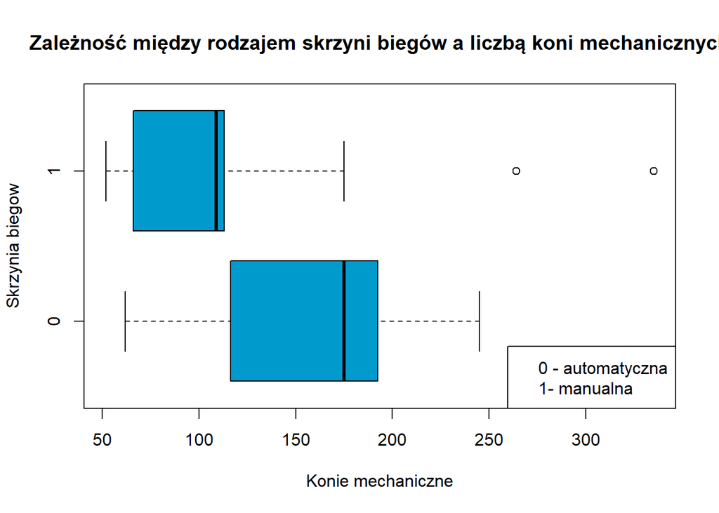

```r
boxplot(mtcars$hp~mtcars$am, col = "deepskyblue3", horizontal = TRUE,
        xlab = "Konie mechaniczne", ylab = "Skrzynia biegow",
        main = "Zależność między rodzajem skrzyni biegów a liczbą koni mechanicznych")
legend("bottomright", legend = c("0 - automatyczna","1- manualna"))
```

```r
top <- mtcars %>%
  dplyr::select(am,hp) %>%
  arrange(desc(hp))%>%
  top_n(2,hp)
top
```

```
##                am  hp
## Maserati Bora   1 335
## Ford Pantera L  1 264
```

Samochody z automatyczną skrzynią biegów maja przeciętnie więcej koni mechanicznych (wyższa średnia, kwartyle), ale 2 samochody z skrzyniami manualnymi przewyższają max z automatycznych, ponieważ są to samochody sportowe

**Wykres 2**

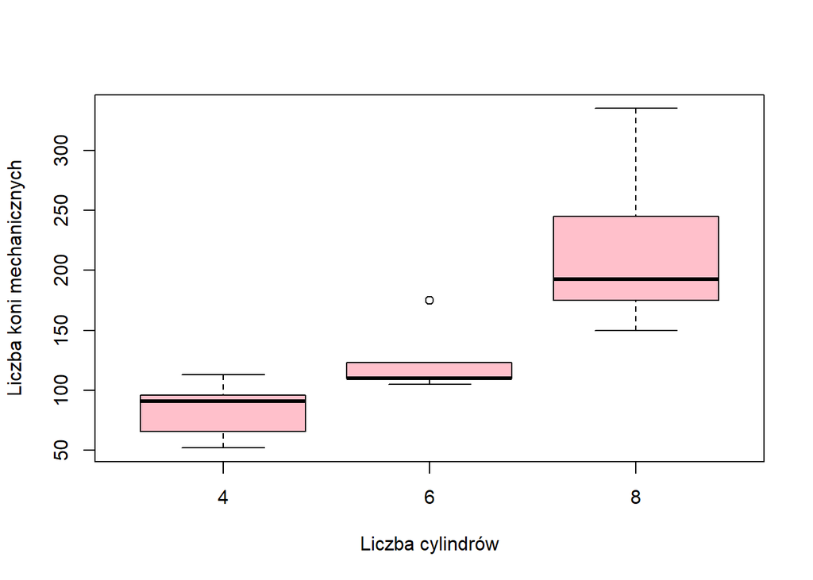

```r
par(mfrow = c(1,1))
boxplot(mtcars$hp~mtcars$cyl, col = "pink", xlab = "Liczba cylindrów",
        ylab = "Liczba koni mechanicznych")
```

Większa liczba cylindrów wiąże się z wyższą przeciętną liczbą koni mechanicznych, samochody z 8 cylindrami mają największy rozstęp liczby KM

**Wykres 3**

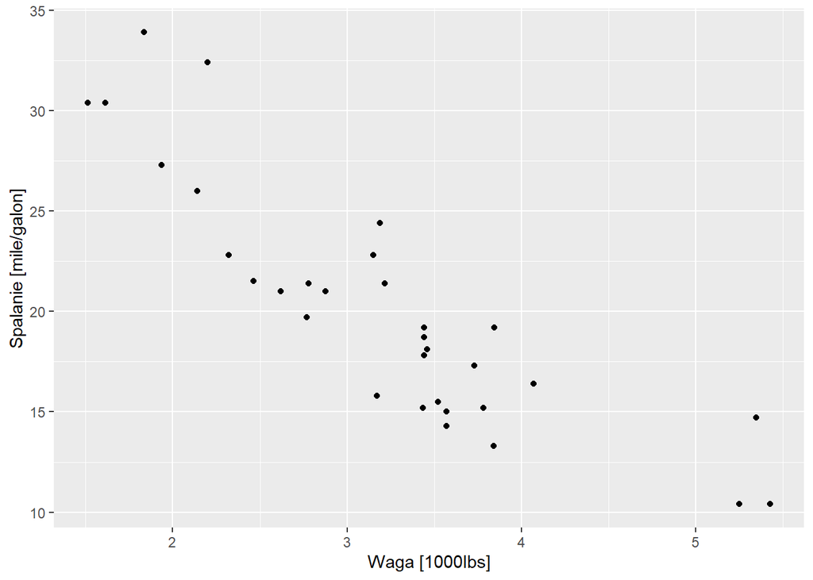

```r
library(ggplot2)
qplot(x = mtcars$wt, y = mtcars$mpg, ylab = "Spalanie [mile/galon]", xlab="Waga [1000lbs]")
```

Występuje korelacja między wagą samochodu a spalaniem - im większa waga tym większe spalanie

**Wykres 4**

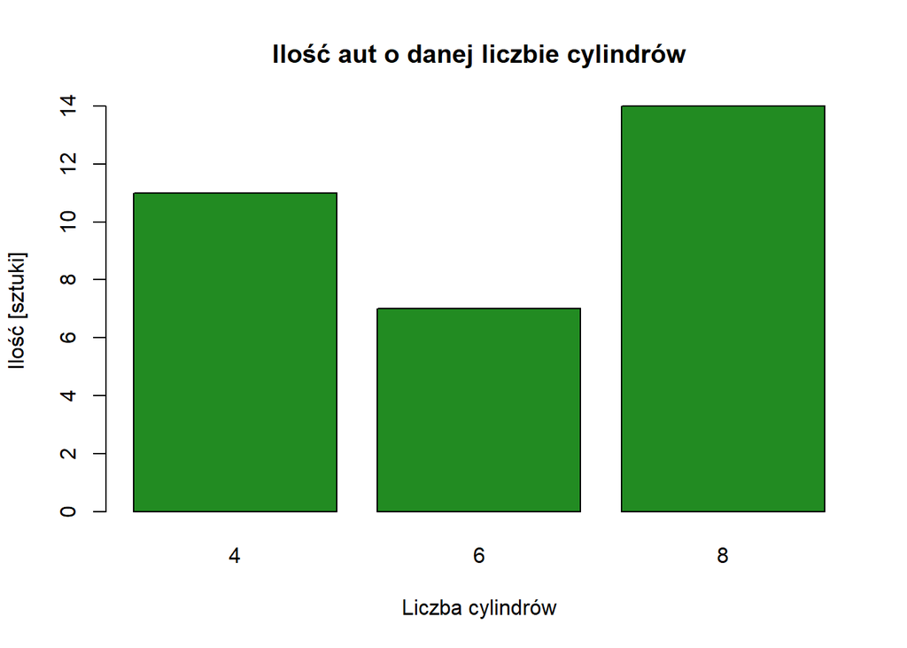

```r
barplot(table(mtcars$cyl),col = "forestgreen",
        main = "Ilość aut o danej liczbie cylindrów",
        xlab= "Liczba cylindrów", ylab= "Ilość [sztuki]")
```

W zestawie mtcars najwięcej jest aut, które posiadają 8 cylindrów

**Wykres 5**

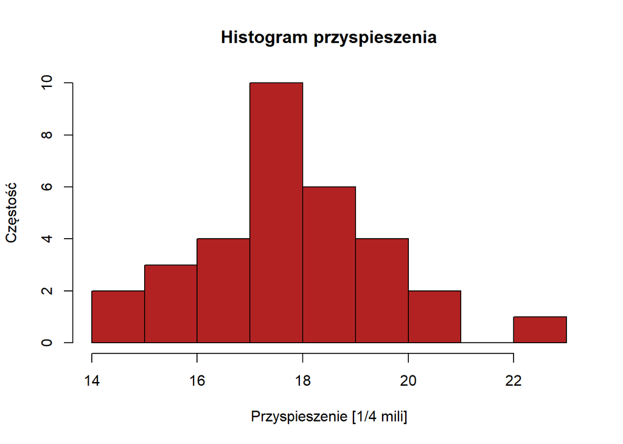

```r
hist(mtcars$qsec, main = "Histogram przyspieszenia",
     xlab = "Przyspieszenie [1/4 mili]", ylab = "Częstość",
     col = "firebrick")
```